# Bifurcations

- 1D flows seem to have one of two behaviour
  - Settle down to an equilibrium point
  - Fly away to infinity
- Apart from this we may have a behaviour where
  - Fixed points are created/destroyed
  - Stability of these points are changed

We will study here the bifurcations of flows on a 1D line Let's consider the first example: $\dot{x} = r + x^2$

```matlab
set(0, "defaultlinelinewidth", 2);
set (0, "defaulttextfontname", "TimesNewRoman")
set (0, "defaulttextfontsize", 20)
set (0, "DefaultAxesFontName", "TimesNewRoman")
set(0, 'DefaultAxesFontSize', 20)

clear;
clc; close all;

h.ax = axes ("position", [0.05 0.4 0.5 0.5]);  #reduce plot windows size to accomodate sliders

function update_plot (obj, init = false)
  ## gcbo holds the handle of the control
  h = guidata (obj);
  replot = false;
  recalc = false;
  switch (gcbo)                       # If we make any change then we replot
    case {h.print_pushbutton}
      fn =  uiputfile ("*.png");
      print (fn);
    case {h.slider1}
      recalc = true;
    end

    if (recalc || init)
      r = -2 + 4*get (h.slider1, "value");
      set (h.label1, "string", sprintf ("r: %.1f", r));
      x = linspace(-2,2);
      xd = r + x.^2;
      h.plot = plot(x, xd, x, 0.*x, '-k');


      guidata (obj, h);
    else
      set (h.plot, "ydata", y);
    end
  end

  # specify the GUI plot properties like sliders and label formatting

  ## print figure
  h.print_pushbutton = uicontrol ("style", "pushbutton",
  "units", "normalized",
  "string", "print plot\n(pushbutton)",
  "callback", @update_plot,
  "position", [0.6 0.45 0.35 0.09]);
  ## guess
  h.label1 = uicontrol ("style", "text",
  "units", "normalized",
  "string", "Guess:",
  "horizontalalignment", "left",
  "position", [0.05 0.25 0.35 0.08]);

  h.slider1 = uicontrol ("style", "slider",
  "units", "normalized",
  "string", "slider",
  "callback", @update_plot,
  "value", 0.1,
  "position", [0.05 0.20 0.35 0.06]);



  set (gcf, "color", get(0, "defaultuicontrolbackgroundcolor"))
  guidata (gcf, h)
  update_plot (gcf, true);
```

We can then plot the equilibrium points as the parameter `r` is varied. Along with that we can also plot whether that particular point is a stable or unstable point. This gives a clear identification of the nature of the roots.

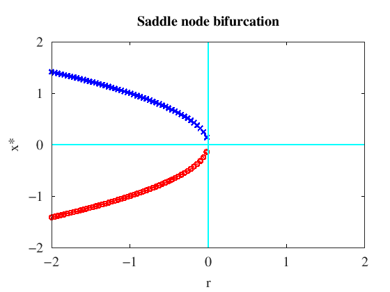

```matlab
function y=f(x, r)
    y = r + x.^2;
end
function dy=dfdx(x, r)
    dy=2*x;
end
x = linspace(-2, 2);
r_a = linspace(-2, 2);
for r = r_a
    [sol, fval, info]= fsolve(@(x) f(x, r), [-2;2]);
    if info == 1 # Solution has convered
      count=0;
        for i = 1:length(sol)
            root = sol(i);
            slope_at_root = dfdx(root, r);
            if slope_at_root > 0
                plot(r, root, 'bx')
            else
                plot(r, root, 'ro')
                hold on
           end
        end
    end
end
line ([min(r_a) max(r_a)], [0 0], "linestyle", "-", "color", "c");
line ([0 0], [min(r_a) max(r_a)],"linestyle", "-", "color", "c");
xlim([min(r_a) max(r_a)])
xlabel("r");
ylabel("x*");
title("Saddle node bifurcation")
```

The above diagram clearly elucidates how increasing the parameter `r` beyond 0 yields no equilibrium point while for $r<0$ we have one stable and one unstable branch. This is an example of a saddle node bifurcation.

In the example below, we show the same saddle node bifurcation in a slightly distored form. The normal form of the equation below, i.e. $\dot{x} = r - x - \exp{-x}$ is of the same form as $\dot{x} = r + x^2$

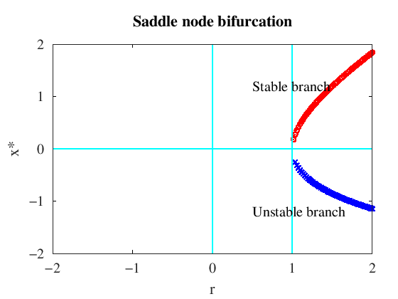

```matlab
function y=f(x, r)
    y= r - x - exp(-x);
end
function dy=dfdx(x, r)
    dy= -1 + exp(-x);
end
x = linspace(-2, 2);
r_a = linspace(-2, 2, 200);

for r = r_a
    [sol, fval, info]= fsolve(@(x) f(x, r), [-2;2]);
    if info == 1 # Solution has convered
        for i = 1:length(sol)
            root = sol(i);
            slope_at_root = dfdx(root, r);
            if slope_at_root > 0
                plot(r, root, 'bx')
            else
                plot(r, root, 'ro')
                hold on
           end
        end
    end
end
line ([min(r_a) max(r_a)], [0 0], "linestyle", "-", "color", "c");
line ([0 0], [min(r_a) max(r_a)],"linestyle", "-", "color", "c");
line ([1 1], [min(r_a) max(r_a)],"linestyle", "-", "color", "c");
xlim([min(r_a) max(r_a)])
xlabel("r");
ylabel("x*");
title("Saddle node bifurcation")
text(0.5, -1.2, "Unstable branch")
text(0.5, 1.2, "Stable branch")
```